# 【第一回目 課題２】フレームワークを使わない深層学習 (2): 畳み込み編

次は，フレームワークを使わないで畳み込み層を実装してみます．順伝搬でim2col, 逆伝搬でcol2imを使えば，基本は全結合と同じである，という点がポイントです．im2col, col2imを使わずに実装するのはかなり複雑で，単純に実装すると6重ループになりますので，通常のフレームワークではim2col, col2imで計算するのが一般的です．

順伝搬は，im2col によって，feature mapをim2col表現に展開します．そうすると，畳み込みは フィルタ行列とim2col行列の行列積として表現できます． つまり，im2col + 全結合層 と等価になります．

逆伝搬は，逆をたどれば良いので，全結合の逆伝搬 + im2col表現のfeature mapへの逆変換 (col2im変換)となります．

まとめると，im2col, col2imの変換ができれば，あとは全結合の順伝搬計算，逆伝搬計算がそのまま利用できます．

では，im2col, col2im を実装してみましょう．

```python
import math
import numpy as np
```

さあ，Convクラスを実装します．課題1のFCクラスを継承してもいいですが，コードを再利用して，独立に実装してみます． **call**(), backfard() に加えて，im2col, col2im関数を追加します．

順伝搬は，最初にim2colの呼び出し，次にFcと同じ行列の積和演算，最後に追加で， (n_filter,out_h$\times$out_w) のサイズの出力を (n_filter,out_h,out_w) にreshapeして，3次元のfeature mapに変形して出力します．

逆伝搬は，最初に(n_filter,out_h,out_w)のfeature mapに関する勾配を　(n_filter,out_h$\times$out_w) の行列に変換して， Fcの時と同じ逆伝搬計算を行います．最後に，dEdyに関して，col2im変換を行って，3次元のfeature mapに変形して出力します．

```python
class Conv:
    def __init__(self,c,h,w,n_filter,pad=0,stride=1,relu=True, seed=0):
        self.filter=(c,w,h)
        self.filter_c=c; self.filter_h=h; self.filter_w=w
        self.n_filter=n_filter
        self.pad=pad
        self.stride=stride
        self.relu=relu
        n_in=c*w*h
        self.n_in=n_in
        n_out=n_filter
        # 学習パラメータは, 重み行列w(=フィルタ), バイアス項b
        # サイズは以下の通り
        self.size_w = (n_out,n_in)
        self.size_b = (n_out,1)
        # w,b は全結合層の学習パラメータ．
        # ReLuも全結合の中にいれてある．
        # ReLU=Trueのときは，Heの初期値．Falseのときは，Xavierの初期値とする．
        # xは直前のforward計算時の入力値．BPの計算時に必要．
        np.random.seed(seed) # 同じ初期値を再現できるように seed を指定します．
        if relu:
            self.w=np.random.normal(0, math.sqrt(2.0/n_in), self.size_w) # Heの初期値
            self.relu0=None # ReLUの順伝搬時に０以下で値が伝搬されない要素のインデックスを記録．BP時に利用．
        else:
            self.w=np.random.normal(0, math.sqrt(1.0/n_in), self.size_w) # Xavierの初期値
        self.b=np.zeros((n_out,1))
        self.x=np.zeros((n_in,1))
        # 誤差逆伝搬(Back-Propagation時の勾配を記録する変数)
        self.dEdx=np.zeros((n_in,1)) # dE/dx を表す　BPの時に直前レイヤに伝わる勾配でδと表現されます．
        self.dEdw=np.zeros((n_out,n_in)) # dE/dw を表す
        self.dEdb=np.zeros((n_out,1)) # dE/db を表す
        self.count=0
        # 以下，MomentamSDGのための設定
        self.mdw=np.zeros((n_out,n_in))
        self.mdb=np.zeros((n_out,1))

    # forward は __call__ を使って定義する．im2col + 行列積和．
    def __call__(self,input):   # 入力はfeature map
        x,out_h,out_w=self.im2col(input) # x のサイズは (self.n_in, out_h*out_w)
        self.x = x
        #self.size_input=input.shape
        #self.size_output=(self.n_filter,out_h,out_w)
        self.out_h=out_h
        self.out_w=out_w
        # w のサイズは，(n_filter, n_in), よって y のサイズは (n_filter,out_h*out_w)
        self.y = np.dot(self.w, x) + self.b
        # ReLUは，値が０以下の要素は，０とする．０とした要素のインデックスは relu0に記録し，BP時に勾配を伝搬させない．
        if self.relu:
            self.relu0= self.y<=0
            self.y[self.relu0]=0
        # 最後に，(n_filter,out_h,out_w) にreshape
        return np.reshape(self.y,(self.n_filter,out_h,out_w))

    # backward は，dE/dy を受け取って，dE/dx を出力．内部では，dE/dw, dE/db を更新
    def backward(self, dEdy0):
        dEdy=np.reshape(dEdy0,(self.n_filter,self.out_h*self.out_w))
        # 順伝搬時に値が０以下だった要素は勾配を０として，勾配伝搬しない．
        if self.relu:
            dEdy[self.relu0]=0
        dydx = np.transpose(self.w)  # dWx/dx= np.transpose(W) であることより．
        dydw = np.transpose(self.x)  # dWx/dW= np.transpose(x)
        # dydb = np.ones((self.n_out,1))   #  db/db = np.ones((n_out,1))　１なので特に計算しない．
        # dEdw, dEdb に勾配を加算．dEdx (δ)は前層へ伝搬する勾配で，backwardの返り値とする．
        self.dEdx = np.dot(dydx, dEdy)
        self.dEdw += np.dot(dEdy, dydw)
        self.dEdb += np.c_[np.sum(dEdy, axis=1)]  # channelごとにfeature map 全体が1つのバイアスに対応するので channelごとにsumします．
        # 勾配の平均を取るために，足した勾配のサンプル数を記録．
        # conv の場合は，フィルタを適用した回数．つまり，出力feature mapの画素数
        self.count += (self.out_h*self.out_w)
        # 最後に，col2imでfeature mapに対応するδを求める
        out=self.col2im(self.dEdx)
        return out

    # im2col は，feature map を　縦が1回の畳み込みに必要な局所画像サイズ(filter_c*filter_h*filter_w)，
    # 横が(out_h*out_w) になる行列に変換する関数
    def im2col(self,input):
        c, h, w = input.shape
        out_h = (h + 2*self.pad - self.filter_h)//self.stride + 1
        out_w = (w + 2*self.pad - self.filter_w)//self.stride + 1
        # padding 分をzero paddingで追加したimを生成
        im = np.pad(input, [(0,0), (self.pad, self.pad), (self.pad, self.pad)], 'constant')
        # filterの各x,yの位置ごとに，対応するfeature mapの値を格納し，
        # 最後に transpose -> reshape で，im2col出力行列を生成
        col = np.zeros((c, self.filter_h, self.filter_w, out_h, out_w))

        for y in range(self.filter_h):
            y_max = y + self.stride*out_h
            for x in range(self.filter_w):
                x_max = x + self.stride*out_w
                # filterの位置に応じてずらしてfeature mapをコピー
                # stride>1の時は飛ばしてfeature mapをコピー
                col[:, y, x, :, :] = im[:, y:y_max:self.stride, x:x_max:self.stride]
        # チャネル軸を1番目から3番目に移動して，reshapeして，(filter_c,out_h*out_w)とする
        col = col.transpose(1, 2, 0, 3, 4).reshape((self.n_in, out_h*out_w))
        return col,out_h,out_w

    # col2im は，im2col形式の勾配δをfeature map形式に変換する．逆伝搬で使用．
    def col2im(self,col):
        col_h, col_w = col.shape # (filter_c*filter_h*filter_w, out_h*out_w)
        h = (self.out_h-1)*self.stride + self.filter_h
        w = (self.out_w-1)*self.stride + self.filter_w
        c = self.filter_c

        # サイズ(x,h,w)の im 行列を0で初期化
        im = np.zeros((c,h,w))
        # feature map colの各場所について，勾配を対応するimの場所に加算する
        for j in range(self.out_h):
            for i in range(self.out_w):
                im[:, j:j+self.filter_h, i:i+self.filter_w] += np.reshape(col[:, j * self.out_w + i],(c,self.filter_h,self.filter_w))
        return im[:,self.pad:h-self.pad,self.pad:w-self.pad]

    # 以下は，updater で，Fcと同じ実装です．ちゃんと実装するなら，super classにする方がいいでしょう．
    # 勾配をクリア
    def clear_grad(self):
        self.dEdw=0
        self.dEdb=0
        self.count=0

    # 勾配法で重みをアップデート．countで割って，足しこんだ勾配のサンプル数で平均を取る
    def update(self, lr=0.001):
        self.w -= self.dEdw/self.count * lr
        self.b -= self.dEdb/self.count * lr
        self.clear_grad()

    # 慣性項（モーメンタム項）付きの勾配法
    def updatem(self, lr=0.001, mu=0.9):
        self.mdw = mu*self.mdw - self.dEdw/self.count * lr
        self.mdb = mu*self.mdb - self.dEdb/self.count * lr
        self.w += self.mdw
        self.b += self.mdb
        self.clear_grad()
```

では，ここでは，簡単な問題として，グレーススケール化とエッジ検出のフィルタを3層の畳み込みネットワークで学習してみましょう．

とりあえず，画像1枚だけで学習します．畳み込みはフィルタをスライドさせて演算しますので，スライドさせる分だけ別々のデータで学習を行っているのと等価になります．例えば，3x3のフィルタを320x240の画像で学習すれば，320x240通りでスライドできますので，Fc層での学習を76800回行ったのと等価になります．

```python
from skimage import feature,filters
from PIL import Image
import os
import sys
```

```python
img_org = Image.open('./img/uec.jpg').resize((320,240))
img = np.array(img_org, dtype=np.uint8)
grey = np.array(img_org.convert('L'), dtype=np.uint8)
edge = feature.canny(grey,sigma=2)  # Canny でエッジ抽出
# edge = filters.sobel(grey) # Sobel でエッジ抽出
edge = edge * 255
```

読み込んだ画像と変換した画像を，numpy形式に変換します． (c,h,w) c:チャネル, h:高さ, w:幅 のサイズの3次元配列にします． ここでは画像は320x240で，入力はカラーなので， input: (3,240,320) output: (1,240,320) の大きさです．

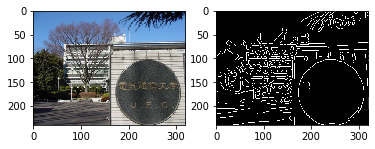

```python
from matplotlib import pyplot as plt
# 以下の２行はJupyter環境の場合のみ必要
%matplotlib inline
from IPython import display

# エッジ検出フィルタ，グレースケール化フィルタの切り替え
use_edge=True  # Falseだとグレースケール化フィルタの学習
if use_edge:
    gt=edge
else:
    gt=grey

plt.subplot(121)
plt.imshow(img)
plt.subplot(122)
plt.imshow(gt,cmap="gray")

# 画素値が [-1,1) の範囲の値になるように変換
input  = (np.asarray(img, dtype=np.float32).transpose(2,0,1)-128)/128.0
output = (np.expand_dims(np.asarray(gt, dtype=np.float32),0)-128)/128.0
```

畳み込み層を3つ用意します． 3x3x10 -> 3x3x10 -> 3x3x1 です． 1,2層目はReLU付きです．

```python
c1=Conv(3,3,3,10,pad=1)
c2=Conv(10,3,3,10,pad=1)
c3=Conv(10,3,3,1,pad=1,relu=0)
```

学習ループです． 学習率lr = 0.01 エポック数200とします．

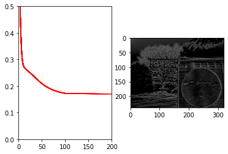

```python
lr=0.01
num_epoch=200
losses=np.array([])
ep=np.array([])

# 表示エリアの設定
fig=plt.figure()
fig1 = fig.add_subplot(121)
fig2 = fig.add_subplot(122)

for epoch in range(num_epoch):
    if epoch>0 and epoch%100==0:
        lr*=0.1
    # 順伝搬計算
    y=c3(c2(c1(input)))
    # 誤差微分値，誤差値を計算します．
    dEdx=y-output
    loss=np.sum(dEdx**2)*0.5/(y.shape[1]*y.shape[2])
    print("epoch:",epoch," loss:",loss," lr:",lr)
    # dEdx (δ)を計算して，逆伝搬します．
    dEdx=c3.backward(dEdx)
    dEdx=c2.backward(dEdx)
    dEdx=c1.backward(dEdx)
    # 順伝搬，逆伝搬を行ったら，SGDで重みを更新
    # out_h*out_w 分の順伝搬の勾配がすべて合計されていますので，
    # batchsize 1 でも，実質batchisizeは out_h*out_w (例えば，320*240だと76800)になります．
    c1.update(lr)
    c2.update(lr)
    c3.update(lr)

    losses=np.append(losses,loss)
    ep=np.append(ep,epoch)
    if epoch%10==0:
        display.clear_output(wait = True)
        fig1.axis([0, num_epoch, 0, 0.5])
        fig1.plot(ep,losses,"r")
        out=(y.squeeze()+1.0)*128.0 # 表示するときは，[0.256)に戻します．
        fig2.imshow(out,cmap="gray",vmin=0,vmax=255)
        display.display(fig)
        if epoch<num_epoch-1:
            fig2.cla()

display.clear_output(wait = True)
fig1.plot(ep,losses,"r")
fig2.imshow(out,cmap="gray",vmin=0,vmax=255)
```

```python
print("loss:",loss)
```

```
loss: 0.16995797069720445
```

### 課題2

以下の小問の(1)-(5)を解答せよ．

1. 上記のコードにおける畳込み層の順伝搬，逆伝搬の計算方法を説明せよ．さらに，自分で用意した画像に対して，上記のコードを実行せよ．
2. モデルパラメータ（例えば，10->20) を変化させて，結果を比較せよ．(特に最終loss値)
3. 学習率を変化させて挙動を観察せよ．
4. 1,2層にReLUを入れた場合と，3層ともReLUなしの場合の結果を比較せよ．
5. モーメンタムSDGに変更して，ノーマルなSDGとの違いを観察せよ．

## 1. 上記のコードにおける畳込み層の順伝播，逆伝播の計算方法を説明せよ．さらに，自分で用意した画像に対して，上記のコードを実行せよ．

### 順伝播

入力の特徴マップ（画像）を，im2colを用いてパッチごとに行列計算できる形式に変換し，重みフィルタwを掛けて，バイアスbを加算した後に，活性化関数ReLUを適用し，reshapeで出力次元（画像）に整える演算を行う．

[figure not shown]

(出典：我妻，Udemy「ディープラーニング」第45節，畳み込み層の実装)

### 逆伝播

出力の勾配dE/dy（行列）から，誤差逆伝搬法を用いてdEdx(δ)等を計算することで、col2im（im2colと逆の演算）を用いて，入力の特徴マップ（画像）を求める演算を行う．

[figure not shown]

(出典：我妻，Udemy「ディープラーニング」第45節，畳み込み層の実装)

```python
img_org = Image.open('./img/dali.jpg').resize((320,240))
img = np.array(img_org, dtype=np.uint8)
grey = np.array(img_org.convert('L'), dtype=np.uint8)
edge = feature.canny(grey,sigma=2)  # Canny でエッジ抽出
# edge = filters.sobel(grey) # Sobel でエッジ抽出
edge = edge * 255
```

[figure not shown]

```python
from matplotlib import pyplot as plt
# 以下の２行はJupyter環境の場合のみ必要
%matplotlib inline
from IPython import display

# エッジ検出フィルタ，グレースケール化フィルタの切り替え
use_edge=True  # Falseだとグレースケール化フィルタの学習
if use_edge:
    gt=edge
else:
    gt=grey

plt.subplot(121)
plt.imshow(img)
plt.subplot(122)
plt.imshow(gt,cmap="gray")

# 画素値が [-1,1) の範囲の値になるように変換
input  = (np.asarray(img, dtype=np.float32).transpose(2,0,1)-128)/128.0
output = (np.expand_dims(np.asarray(gt, dtype=np.float32),0)-128)/128.0
```

[figure not shown]

```python
lr=0.01
num_epoch=200
losses=np.array([])
ep=np.array([])

# 表示エリアの設定
fig=plt.figure()
fig1 = fig.add_subplot(121)
fig2 = fig.add_subplot(122)

for epoch in range(num_epoch):
    if epoch>0 and epoch%100==0:
        lr*=0.1
    # 順伝搬計算
    y=c3(c2(c1(input)))
    # 誤差微分値，誤差値を計算します．
    dEdx=y-output
    loss=np.sum(dEdx**2)*0.5/(y.shape[1]*y.shape[2])
    print("ephoch:",epoch," loss:",loss," lr:",lr)
    # dEdx (δ)を計算して，逆伝搬します．
    dEdx=c3.backward(dEdx)
    dEdx=c2.backward(dEdx)
    dEdx=c1.backward(dEdx)
    # 順伝搬，逆伝搬を行ったら，SDGで重みを更新
    # out_h*out_w 分の順伝搬の勾配がすべて合計されていますので，
    # batchsize 1 でも，実質batchisizeは out_h*out_w (例えば，320*240だと76800)になります．
    c1.update(lr)
    c2.update(lr)
    c3.update(lr)

    losses=np.append(losses,loss)
    ep=np.append(ep,epoch)
    if epoch%10==0:
        display.clear_output(wait = True)
        fig1.axis([0, num_epoch, 0, 0.5])
        fig1.plot(ep,losses,"r")
        out=(y.squeeze()+1.0)*128.0 # 表示するときは，[0.256)に戻します．
        fig2.imshow(out,cmap="gray",vmin=0,vmax=255)
        display.display(fig)
        if epoch<num_epoch-1:
            fig2.cla()

display.clear_output(wait = True)
fig1.plot(ep,losses,"r")
fig2.imshow(out,cmap="gray",vmin=0,vmax=255)
```

```python
print("loss:",loss)
```

```
loss: 0.10725019795325286
```

## 2. モデルパラメータ（例えば，10->20) を変化させて，結果を比較せよ．(特に最終loss値)

```python
# モデルパラメータを20に変更
c1=Conv(3,3,3,20,pad=1)
c2=Conv(20,3,3,20,pad=1)
c3=Conv(20,3,3,1,pad=1,relu=0)
```

[figure not shown]

```python
lr=0.01
num_epoch=200
losses=np.array([])
ep=np.array([])

# 表示エリアの設定
fig=plt.figure()
fig1 = fig.add_subplot(121)
fig2 = fig.add_subplot(122)

for epoch in range(num_epoch):
    if epoch>0 and epoch%100==0:
        lr*=0.1
    # 順伝搬計算
    y=c3(c2(c1(input)))
    # 誤差微分値，誤差値を計算します．
    dEdx=y-output
    loss=np.sum(dEdx**2)*0.5/(y.shape[1]*y.shape[2])
    print("ephoch:",epoch," loss:",loss," lr:",lr)
    # dEdx (δ)を計算して，逆伝搬します．
    dEdx=c3.backward(dEdx)
    dEdx=c2.backward(dEdx)
    dEdx=c1.backward(dEdx)
    # 順伝搬，逆伝搬を行ったら，SDGで重みを更新
    # out_h*out_w 分の順伝搬の勾配がすべて合計されていますので，
    # batchsize 1 でも，実質batchisizeは out_h*out_w (例えば，320*240だと76800)になります．
    c1.update(lr)
    c2.update(lr)
    c3.update(lr)

    losses=np.append(losses,loss)
    ep=np.append(ep,epoch)
    if epoch%10==0:
        display.clear_output(wait = True)
        fig1.axis([0, num_epoch, 0, 0.5])
        fig1.plot(ep,losses,"r")
        out=(y.squeeze()+1.0)*128.0 # 表示するときは，[0.256)に戻します．
        fig2.imshow(out,cmap="gray",vmin=0,vmax=255)
        display.display(fig)
        if epoch<num_epoch-1:
            fig2.cla()

display.clear_output(wait = True)
fig1.plot(ep,losses,"r")
fig2.imshow(out,cmap="gray",vmin=0,vmax=255)
```

```python
print("loss:",loss)
```

```
loss: 0.13087083964673246
```

モデルパラメータを変化させた際のloss値の変化は，次の結果になった．

| モデルパラメータ | $loss$ |
| --- | --- |
| 10 | 0.1072 |
| 20 | 0.1308 |

一般に，モデルパラメータ（今回のケースでは，フィルタ数n_filter）を増加させることで， 精度が向上（損失が低減）すると考えられるが，本実験においては，異なる結果が得られた． 赤線のグラフから，選定した画像において，0epochの時点で損失が0.25付近と小さかったため， 学習による損失低減効果が，大きくなかったものと考えられる．

## 3. 学習率を変化させて挙動を観察せよ．

```python
img_org = Image.open('./img/uec.jpg').resize((320,240))
img = np.array(img_org, dtype=np.uint8)
grey = np.array(img_org.convert('L'), dtype=np.uint8)
edge = feature.canny(grey,sigma=2)  # Canny でエッジ抽出
# edge = filters.sobel(grey) # Sobel でエッジ抽出
edge = edge * 255
```

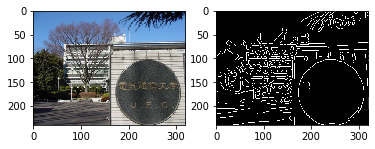

```python
from matplotlib import pyplot as plt
# 以下の２行はJupyter環境の場合のみ必要
%matplotlib inline
from IPython import display

# エッジ検出フィルタ，グレースケール化フィルタの切り替え
use_edge=True  # Falseだとグレースケール化フィルタの学習
if use_edge:
    gt=edge
else:
    gt=grey

plt.subplot(121)
plt.imshow(img)
plt.subplot(122)
plt.imshow(gt,cmap="gray")

# 画素値が [-1,1) の範囲の値になるように変換
input  = (np.asarray(img, dtype=np.float32).transpose(2,0,1)-128)/128.0
output = (np.expand_dims(np.asarray(gt, dtype=np.float32),0)-128)/128.0
```

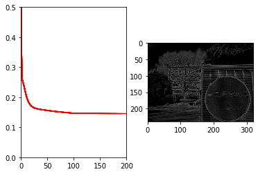

```python
lr=0.05 # 学習率を5倍とする
num_epoch=200
losses=np.array([])
ep=np.array([])

# 表示エリアの設定
fig=plt.figure()
fig1 = fig.add_subplot(121)
fig2 = fig.add_subplot(122)

for epoch in range(num_epoch):
    if epoch>0 and epoch%100==0:
        lr*=0.1
    # 順伝搬計算
    y=c3(c2(c1(input)))
    # 誤差微分値，誤差値を計算します．
    dEdx=y-output
    loss=np.sum(dEdx**2)*0.5/(y.shape[1]*y.shape[2])
    print("ephoch:",epoch," loss:",loss," lr:",lr)
    # dEdx (δ)を計算して，逆伝搬します．
    dEdx=c3.backward(dEdx)
    dEdx=c2.backward(dEdx)
    dEdx=c1.backward(dEdx)
    # 順伝搬，逆伝搬を行ったら，SDGで重みを更新
    # out_h*out_w 分の順伝搬の勾配がすべて合計されていますので，
    # batchsize 1 でも，実質batchisizeは out_h*out_w (例えば，320*240だと76800)になります．
    c1.update(lr)
    c2.update(lr)
    c3.update(lr)

    losses=np.append(losses,loss)
    ep=np.append(ep,epoch)
    if epoch%10==0:
        display.clear_output(wait = True)
        fig1.axis([0, num_epoch, 0, 0.5])
        fig1.plot(ep,losses,"r")
        out=(y.squeeze()+1.0)*128.0 # 表示するときは，[0.256)に戻します．
        fig2.imshow(out,cmap="gray",vmin=0,vmax=255)
        display.display(fig)
        if epoch<num_epoch-1:
            fig2.cla()

display.clear_output(wait = True)
fig1.plot(ep,losses,"r")
fig2.imshow(out,cmap="gray",vmin=0,vmax=255)
```

```python
print("loss:",loss)
```

```
loss: 0.1453557855284571
```

### 考察・挙動

学習率を変化させた際のloss値の変化は，次の結果になった．

| $lr$ | $loss$ |
| --- | --- |
| 0.01 | 0.1699 |
| 0.05 | 0.1453 |

学習率 $lr=0.01$ の際は，約100epochで学習が収束したものの，学習率 $lr=0.05$ の際は，約50epochで素早く収束し， また，損失 $loss$ を0.02前後，低減することが出来た．

上記を勘案すると，学習が収束する前提で，高めの学習率を選定することが出来れば，学習を素早く，かつ精度高く実行することが出来る示唆が得られた．

### 4. 1,2層にReLUを入れた場合（最初の実験例）と，3層ともReLUなしの場合（下記の実験例）の結果を比較せよ．

比較のため，最初の実験例と同様に，学習率 $lr$ を0.01，モデルパラメータを10と設定する．

```python
c1=Conv(3,3,3,10,pad=1, relu=0)
c2=Conv(10,3,3,10,pad=1, relu=0)
c3=Conv(10,3,3,1,pad=1,relu=0)
```

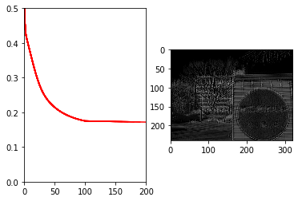

```python
lr=0.01
num_epoch=200
losses=np.array([])
ep=np.array([])

# 表示エリアの設定
fig=plt.figure()
fig1 = fig.add_subplot(121)
fig2 = fig.add_subplot(122)

for epoch in range(num_epoch):
    if epoch>0 and epoch%100==0:
        lr*=0.1
    # 順伝搬計算
    y=c3(c2(c1(input)))
    # 誤差微分値，誤差値を計算します．
    dEdx=y-output
    loss=np.sum(dEdx**2)*0.5/(y.shape[1]*y.shape[2])
    print("ephoch:",epoch," loss:",loss," lr:",lr)
    # dEdx (δ)を計算して，逆伝搬します．
    dEdx=c3.backward(dEdx)
    dEdx=c2.backward(dEdx)
    dEdx=c1.backward(dEdx)
    # 順伝搬，逆伝搬を行ったら，SDGで重みを更新
    # out_h*out_w 分の順伝搬の勾配がすべて合計されていますので，
    # batchsize 1 でも，実質batchisizeは out_h*out_w (例えば，320*240だと76800)になります．
    c1.update(lr)
    c2.update(lr)
    c3.update(lr)

    losses=np.append(losses,loss)
    ep=np.append(ep,epoch)
    if epoch%10==0:
        display.clear_output(wait = True)
        fig1.axis([0, num_epoch, 0, 0.5])
        fig1.plot(ep,losses,"r")
        out=(y.squeeze()+1.0)*128.0 # 表示するときは，[0.256)に戻します．
        fig2.imshow(out,cmap="gray",vmin=0,vmax=255)
        display.display(fig)
        if epoch<num_epoch-1:
            fig2.cla()

display.clear_output(wait = True)
fig1.plot(ep,losses,"r")
fig2.imshow(out,cmap="gray",vmin=0,vmax=255)
```

```python
print("loss:",loss)
```

```
loss: 0.17188951187640028
```

### 比較

ReLUの有無を比較した際のloss値の変化は，次の結果になった．

| $lr$ | $loss$ |
| --- | --- |
| ReLU有 | 0.1699 |
| ReLU無 | 0.1718 |

## 5. モーメンタムSDGに変更して，ノーマルなSDGとの違いを観察せよ．

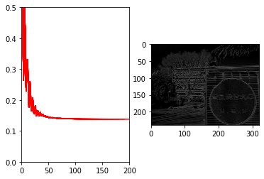

```python
lr=0.01
num_epoch=200
losses=np.array([])
ep=np.array([])

# 表示エリアの設定
fig=plt.figure()
fig1 = fig.add_subplot(121)
fig2 = fig.add_subplot(122)

for epoch in range(num_epoch):
    if epoch>0 and epoch%100==0:
        lr*=0.1
    # 順伝搬計算
    y=c3(c2(c1(input)))
    # 誤差微分値，誤差値を計算します．
    dEdx=y-output
    loss=np.sum(dEdx**2)*0.5/(y.shape[1]*y.shape[2])
    print("ephoch:",epoch," loss:",loss," lr:",lr)
    # dEdx (δ)を計算して，逆伝搬します．
    dEdx=c3.backward(dEdx)
    dEdx=c2.backward(dEdx)
    dEdx=c1.backward(dEdx)
    # 順伝搬，逆伝搬を行ったら，SDGで重みを更新
    # out_h*out_w 分の順伝搬の勾配がすべて合計されていますので，
    # batchsize 1 でも，実質batchisizeは out_h*out_w (例えば，320*240だと76800)になります．

    # updatemでモーメンタムSGDを利用
    c1.updatem(lr)
    c2.updatem(lr)
    c3.updatem(lr)

    losses=np.append(losses,loss)
    ep=np.append(ep,epoch)
    if epoch%10==0:
        display.clear_output(wait = True)
        fig1.axis([0, num_epoch, 0, 0.5])
        fig1.plot(ep,losses,"r")
        out=(y.squeeze()+1.0)*128.0 # 表示するときは，[0.256)に戻します．
        fig2.imshow(out,cmap="gray",vmin=0,vmax=255)
        display.display(fig)
        if epoch<num_epoch-1:
            fig2.cla()

display.clear_output(wait = True)
fig1.plot(ep,losses,"r")
fig2.imshow(out,cmap="gray",vmin=0,vmax=255)
```

```python
print("loss:",loss)
```

```
loss: 0.13790466264732604
```

#### 考察・観察

ノーマルSGDと，モーメンタムSGDとを比較した際のloss値の変化は，次の結果になった．

| SGD type | $loss$ |
| --- | --- |
| normal | 0.1699 |
| momentum | 0.1379 |

モーメンタムSGDは，全結合層の時と同様に，ジグザグの幅が徐々に低減される挙動が見られた． また，損失についても，モーメンタムSGDは約0.03低減されている． 上述を踏まえると，ノーマルSGDより効率の良い学習が出来ていると推察される．